# Prediction of Health Insurance Costs with Linear Regression

The theory here is that the deterministic component of a regression model does such a great job of explaining the dependent variable that it leaves only the intrinsically inexplicable portion of your study area for the error. If it can identify non-randomness in the error term, the independent variables are not explaining everything that they can.

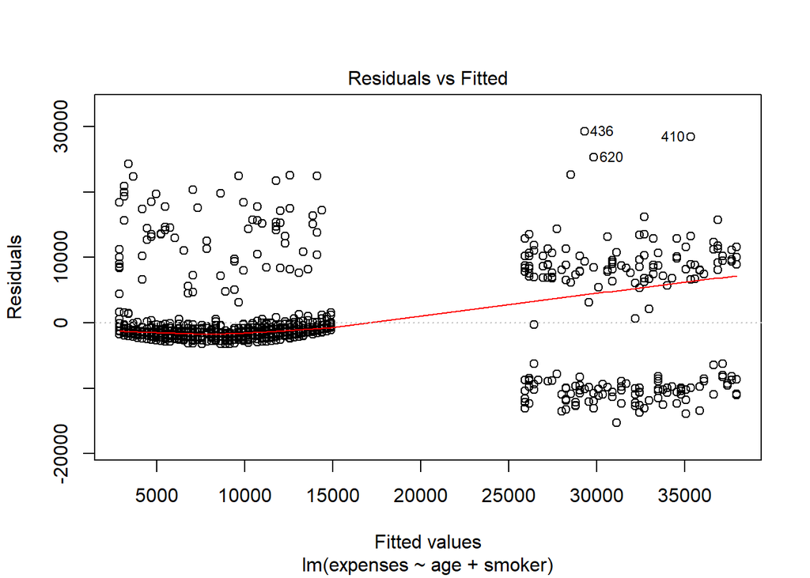

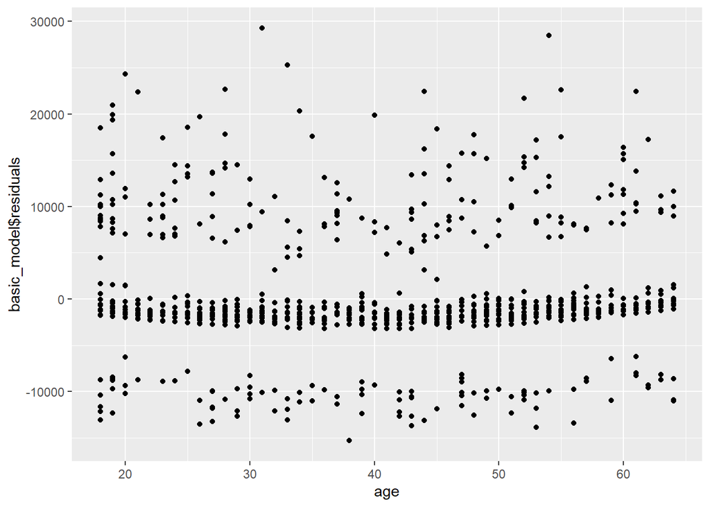

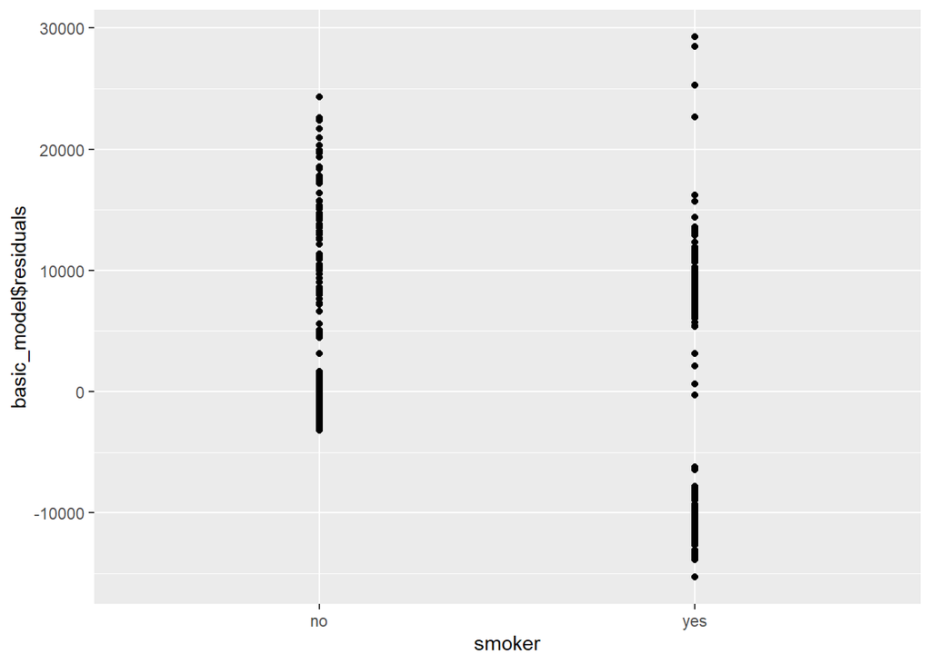

If we add color by “smoker” for the middle plot we get:

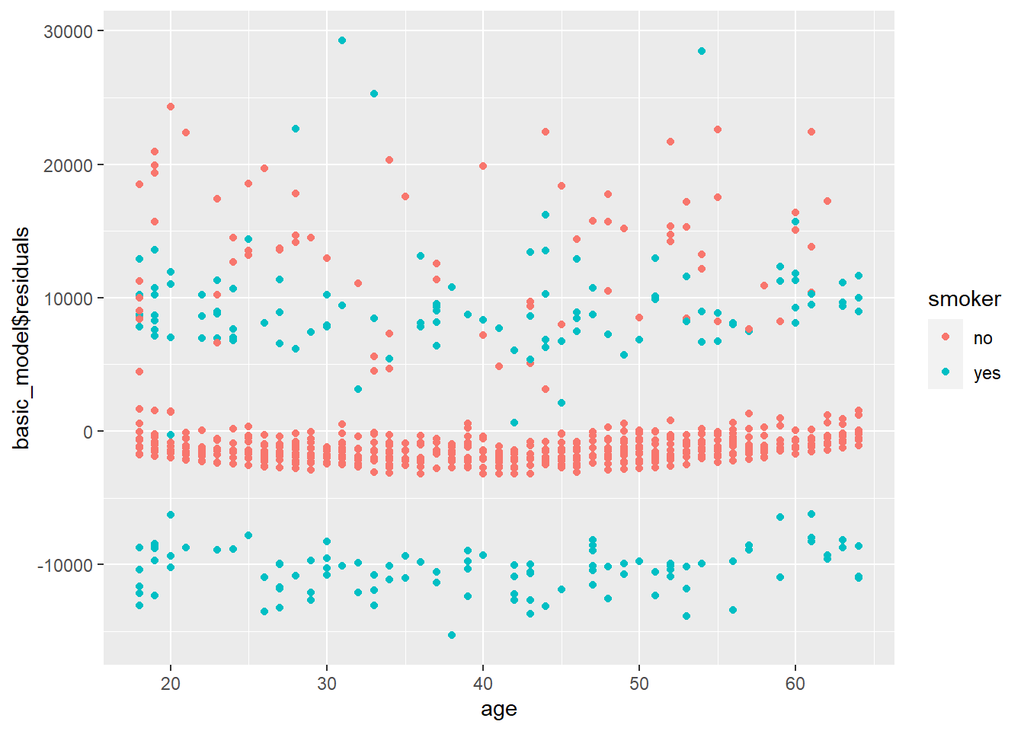

We can see that almost all the points that close to y=0 are points that belongs to non-smokers. We can take advantage of this information and add interaction smoker*age to the improved model.

**Residuals vs variables that arn’t used in the basic model**

We will color the points by “smoker”.

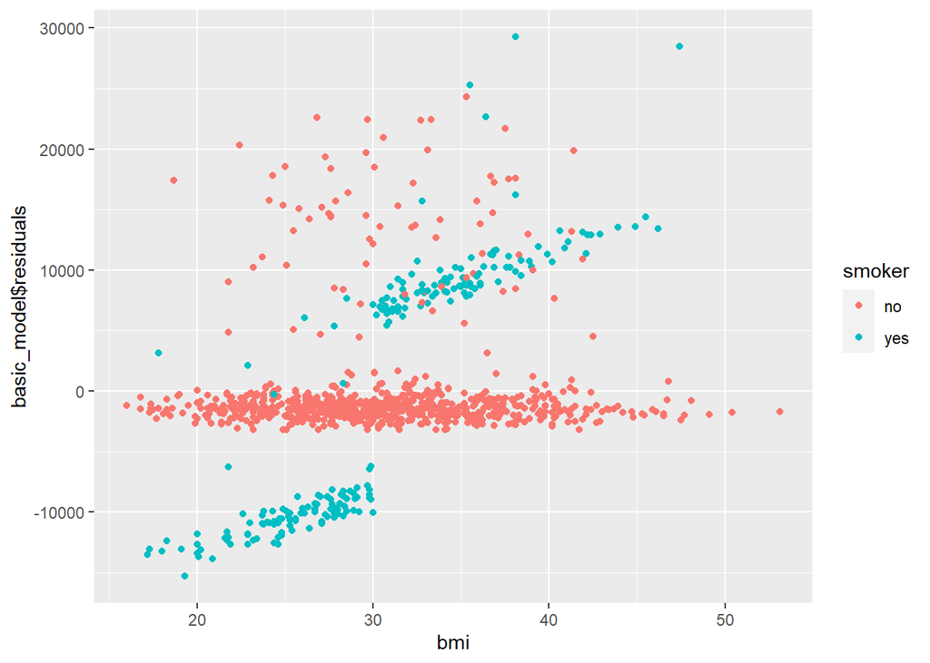

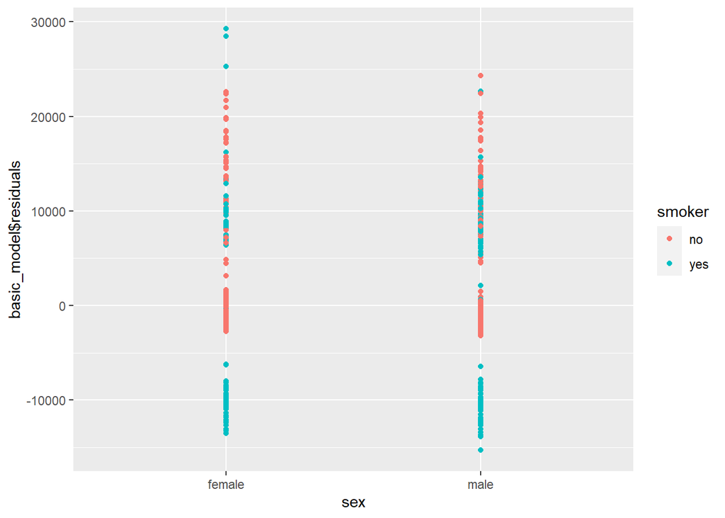

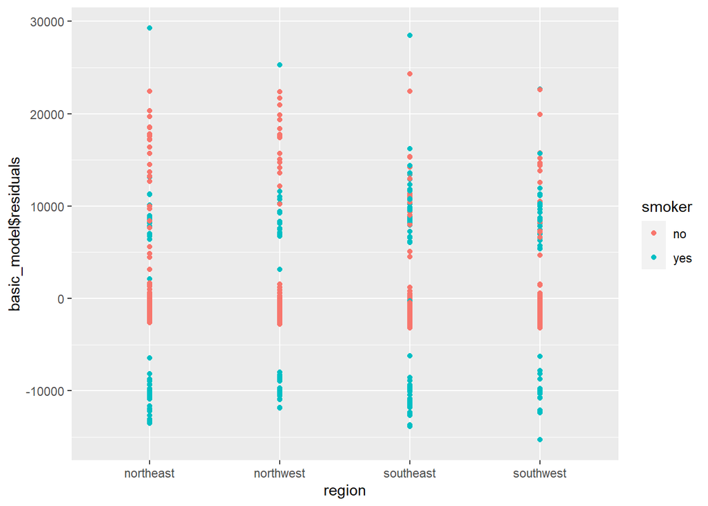

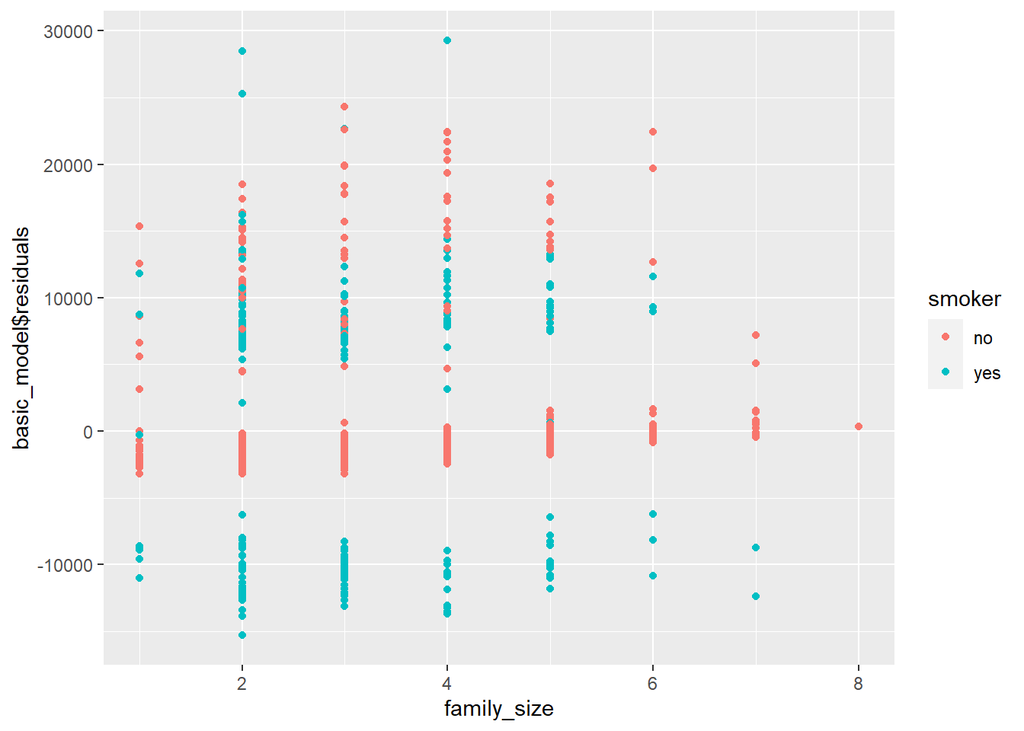

#### **Model Quality**

Even tho some assumptopn are violated in the basic fitted model, we will calculate some model qualty measures:

**R-squared (R2)** is the proportion of variation in the outcome that is explained by the predictor variables. The Higher the R-squared, the better the model.

**Adjusted R-squared**, adjusts the R2 for having too many variables in the model (in higer dimension it is s easier to find linear subspace that fit the data, but it may lead to strong overfitting!)

**AIC** stands for (Akaike’s Information Criteria), a metric developped by the Japanese Statistician, Hirotugu Akaike, 1970. The basic idea of AIC is to penalize the inclusion of additional variables to a model. It adds a penalty that increases the error when including additional terms. The lower the AIC, the better the model.

**BIC** (or Bayesian information criteria) is a variant of AIC with a stronger penalty for including additional variables to the model.

**Mallows Cp:** A variant of AIC developed by Colin Mallows.

```
## # A tibble: 1 x 4
##   r.squared adj.r.squared    AIC    BIC
##       <dbl>         <dbl>  <dbl>  <dbl>
## 1     0.711         0.710 20432. 20452.
```

```
## [1] "Mallows C_p: 125.05"
```

We got $R^2=0.71, Adjusted R^2=0.71$, which is relativly high scores.

#### **Influential Observations**

```
##      StudRes         Hat       CookD
## 247 1.569304 0.007878282 0.006509157
## 318 1.405916 0.007878282 0.005226854
## 410 4.501321 0.005890397 0.039262982
## 436 4.630964 0.005115710 0.036021767
```

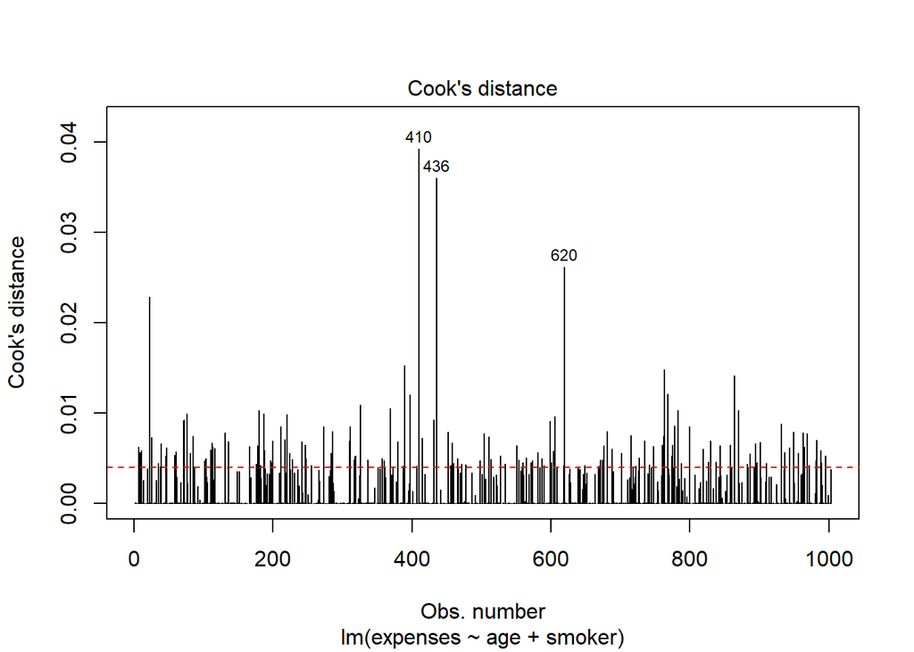

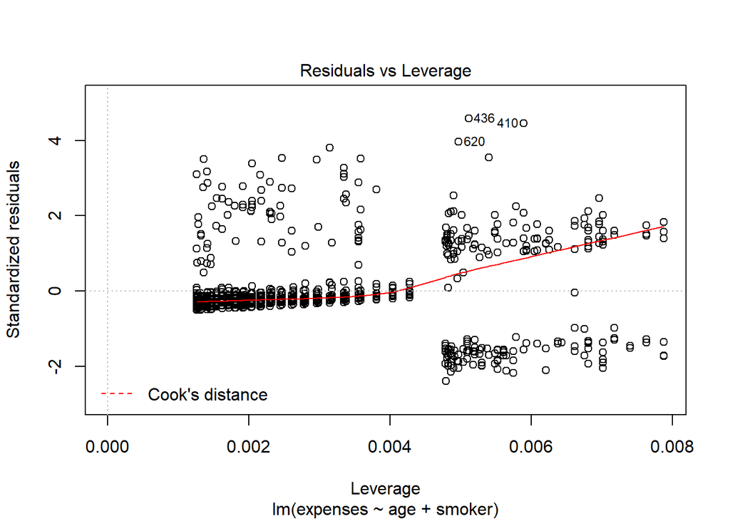

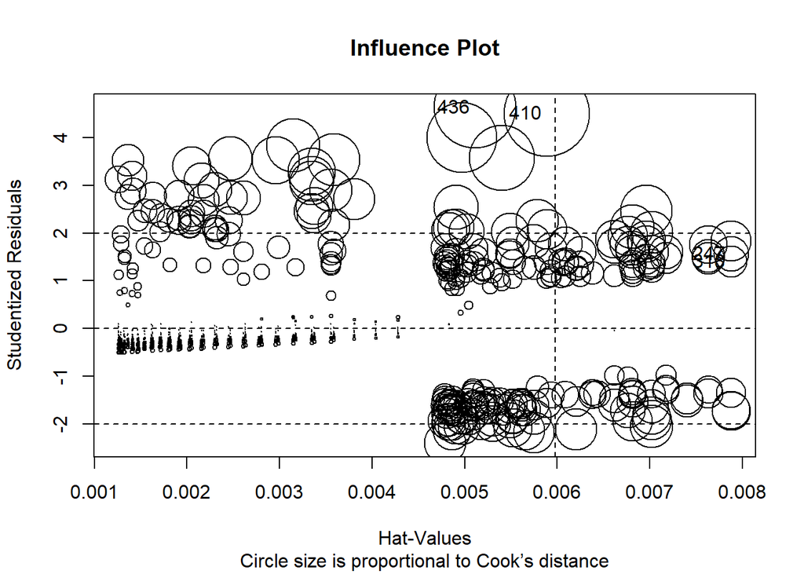

```
##       X age    sex  bmi children smoker    region family_size expenses
## 544 720  58 female 33.4        0     no northwest           2 12231.61
```

```
##       X age    sex bmi children smoker    region family_size expenses
## 578 768  42 female  29        1     no southwest           3  7050.64
```

```
##        X age  sex  bmi children smoker    region family_size expenses
## 820 1088  57 male 31.5        0     no northwest           2 11353.23
```

We didn’t sucssed to identify why these observation are outliers.

### **Improved model**

Now we build an improved model. we add the following variables in addition to “age” and “smoker”:

- sex (as dummy variable)
- children (as dummies)
- region (as dummies)
- age^2 (non-linear variable)
- age^2*smoker (interaction)
- bmi30*smoker (interaction)

“family_size” was excluded since its information is included already in “children”.

In addition we tried to transform the response with ln/sqrt/^-1 functions but it didn’t improve the model, so we left the response as it is.

```r
age2 = (train$age-mean(train$age))^2
bmi30 = ifelse(train$bmi >=30, 1, 0)

improved_model = lm(expenses ~ age + age2*smoker + factor(children) + bmi + sex + bmi30*smoker + region, data=train)

summary(improved_model)
```

```
##
## Call:
## lm(formula = expenses ~ age + age2 * smoker + factor(children) +
##     bmi + sex + bmi30 * smoker + region, data = train)
##
## Residuals:
##      Min       1Q   Median       3Q      Max
## -17098.7  -1747.5  -1215.1   -574.1  23806.1
##
## Coefficients:
##                    Estimate Std. Error t value Pr(>|t|)
## (Intercept)       -6421.762   1130.227  -5.682 1.75e-08 ***
## age                 254.531     10.229  24.884  < 2e-16 ***
## age2                  4.550      1.001   4.547 6.12e-06 ***
## smokeryes         14028.989    620.534  22.608  < 2e-16 ***
## factor(children)1  1105.023    377.411   2.928 0.003491 **
## factor(children)2  1807.289    425.728   4.245 2.39e-05 ***
## factor(children)3  1761.595    486.235   3.623 0.000306 ***
## factor(children)4  4335.044   1062.909   4.078 4.90e-05 ***
## factor(children)5  2092.056   1195.398   1.750 0.080414 .
## bmi                 152.043     39.608   3.839 0.000132 ***
## sexmale            -574.291    287.084  -2.000 0.045728 *
## bmi30             -1330.270    500.596  -2.657 0.008003 **
## regionnorthwest    -310.280    411.429  -0.754 0.450938
## regionsoutheast   -1025.300    409.099  -2.506 0.012362 *
## regionsouthwest   -1188.910    410.824  -2.894 0.003888 **
## age2:smokeryes       -2.286      1.986  -1.151 0.250001
## smokeryes:bmi30   19461.689    706.677  27.540  < 2e-16 ***
## ---
## Signif. codes:  0 '***' 0.001 '**' 0.01 '*' 0.05 '.' 0.1 ' ' 1
##
## Residual standard error: 4503 on 986 degrees of freedom
## Multiple R-squared:  0.8589, Adjusted R-squared:  0.8567
## F-statistic: 375.2 on 16 and 986 DF,  p-value: < 2.2e-16
```

**Check the assumption that the residuals are normaly distributed**

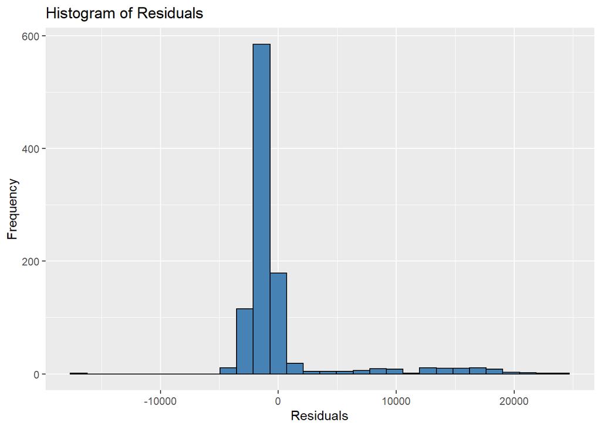

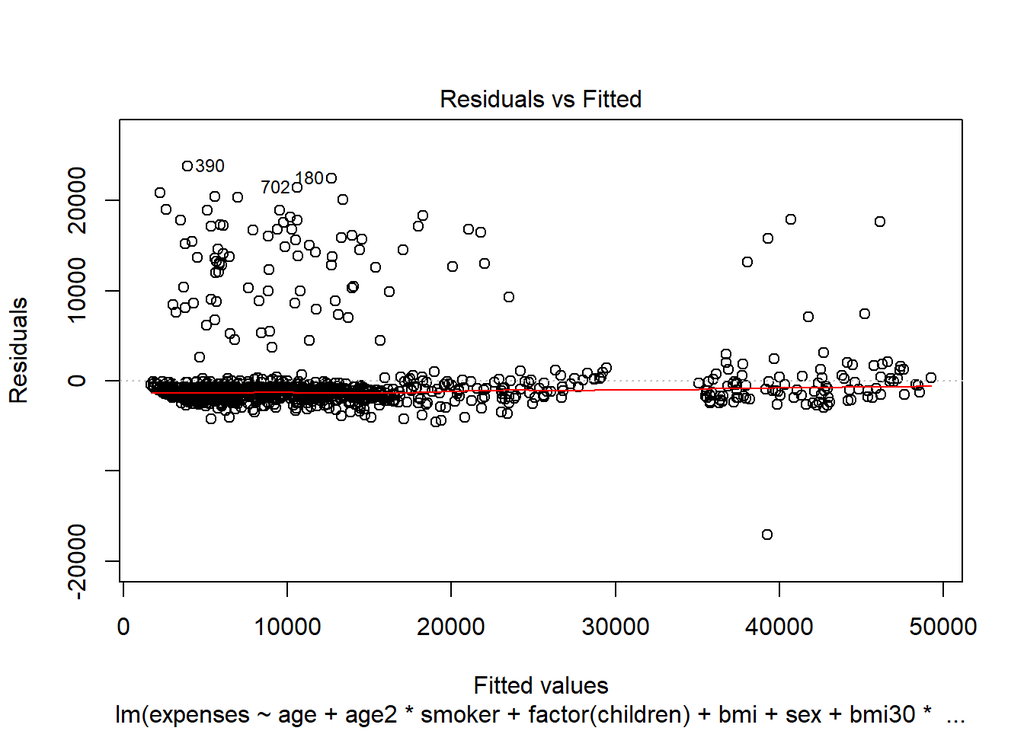

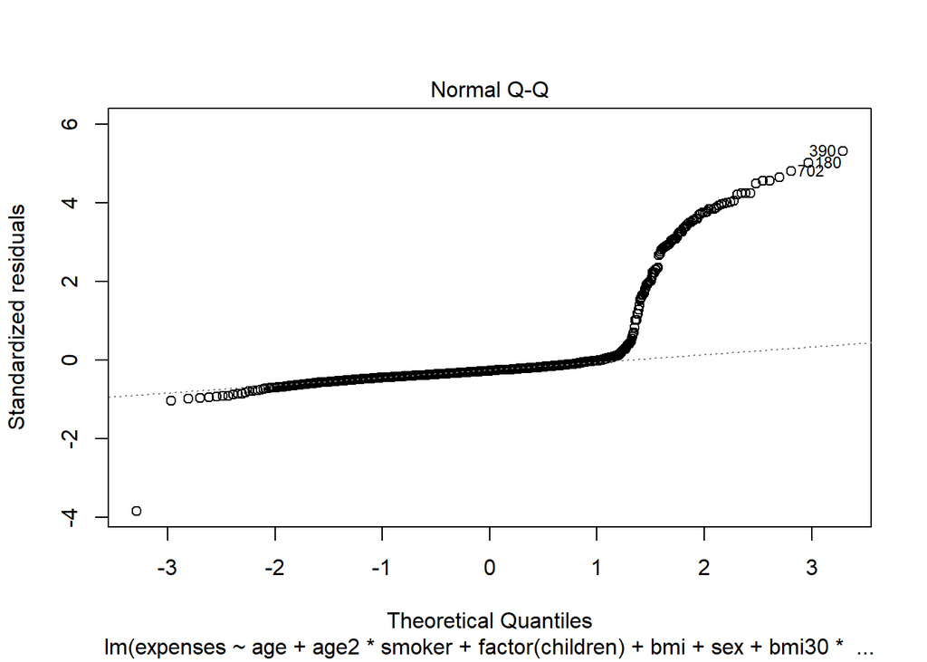

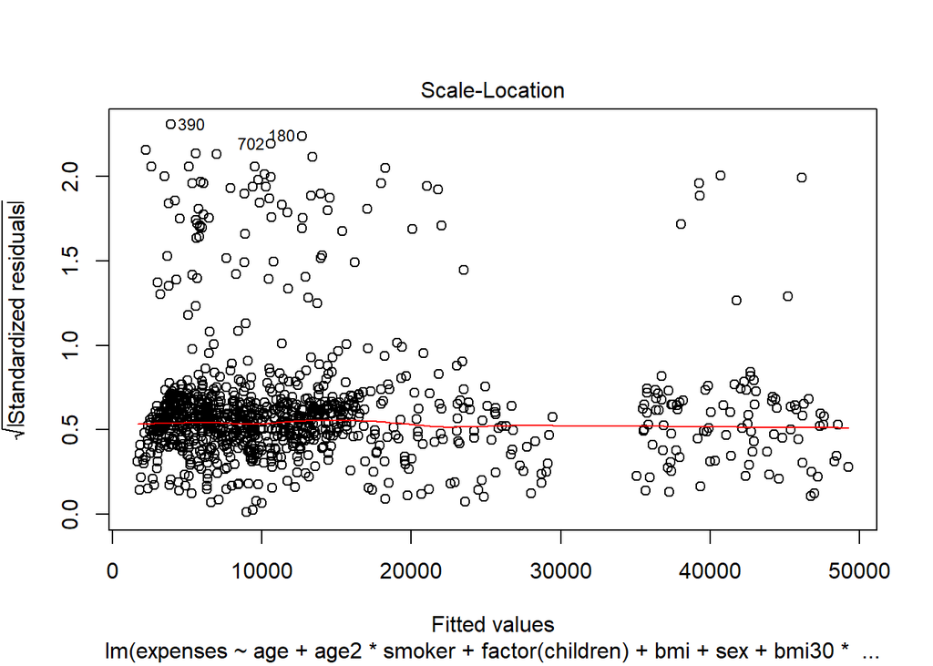

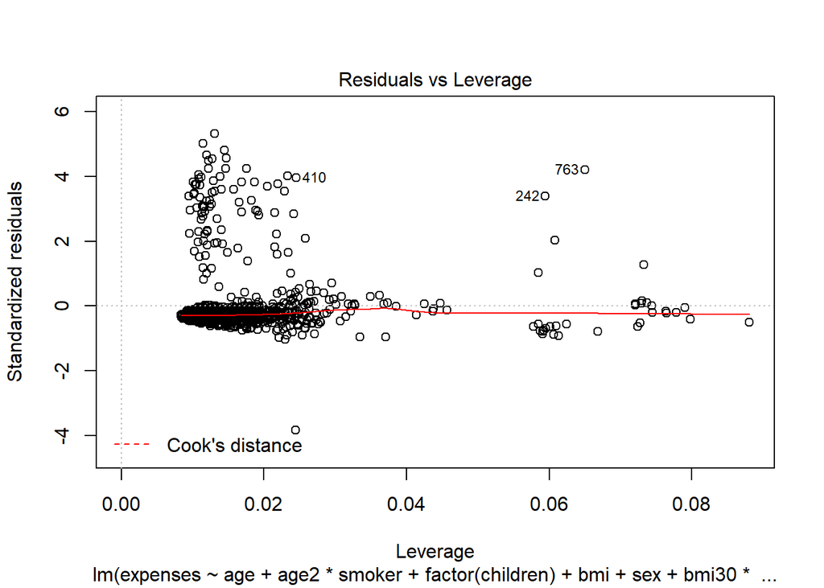

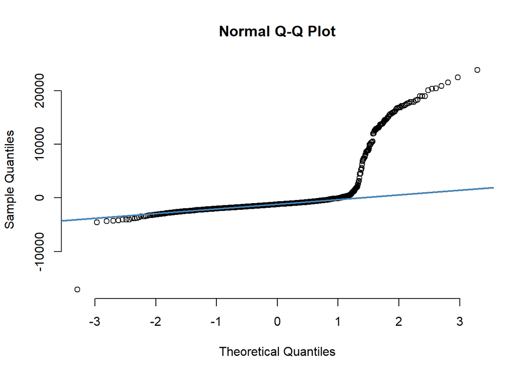

**Check the assumption that the residuals are randomly dispersed around the 0 horizontal axis**

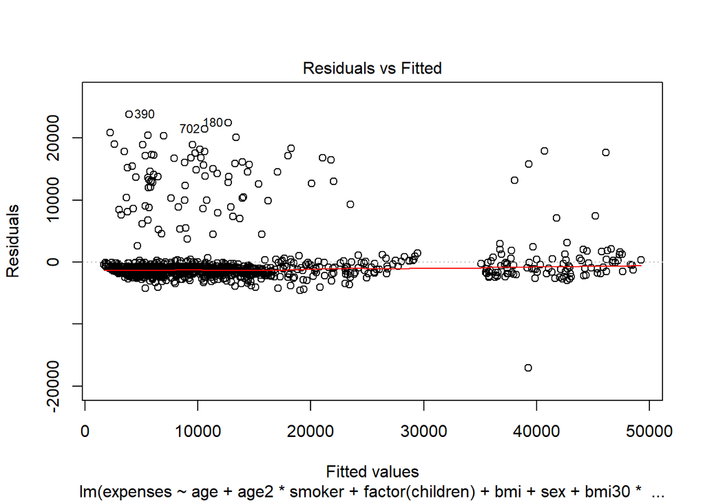

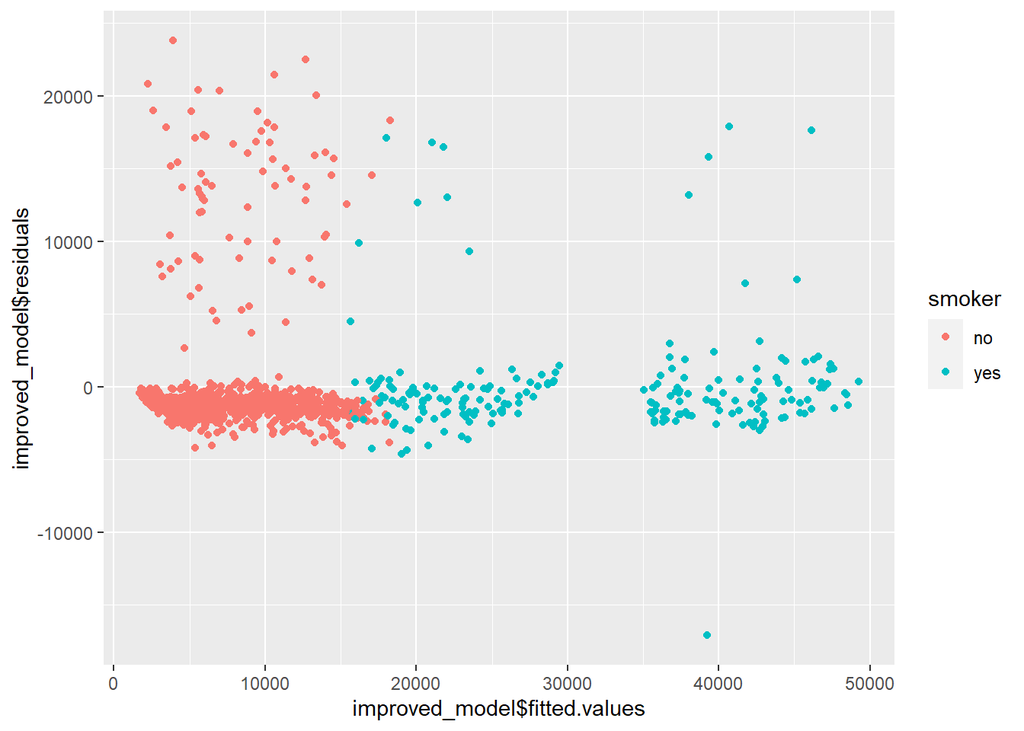

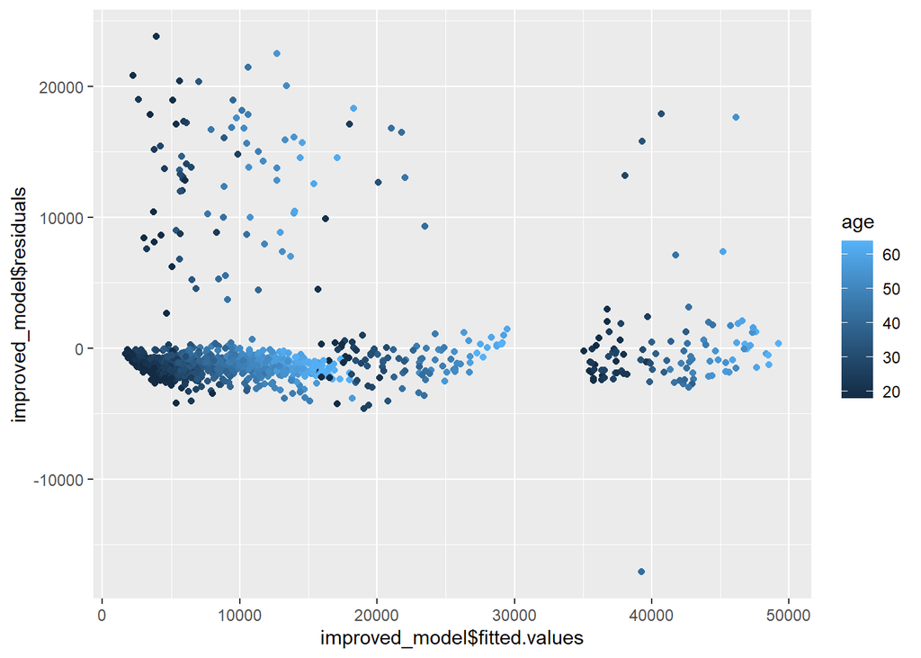

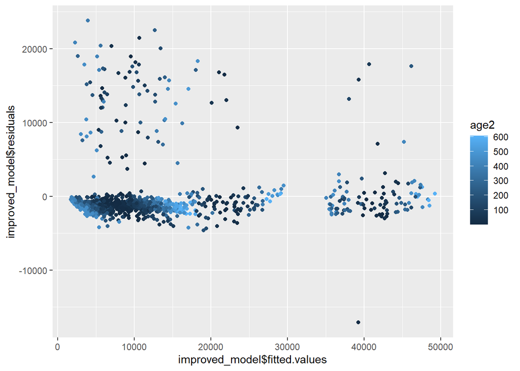

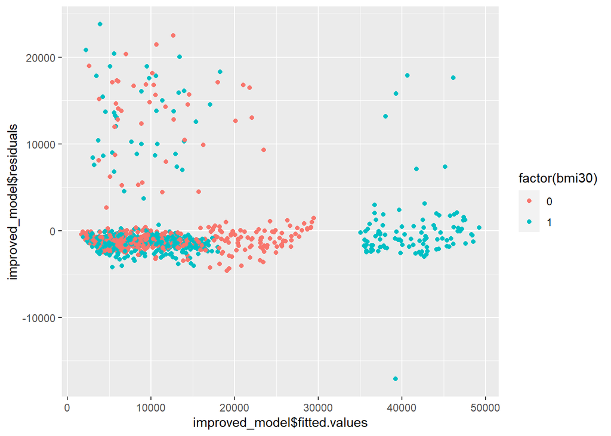

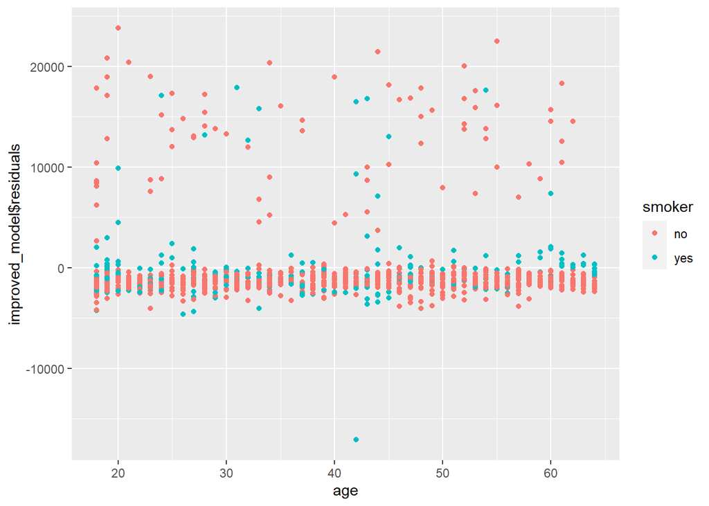

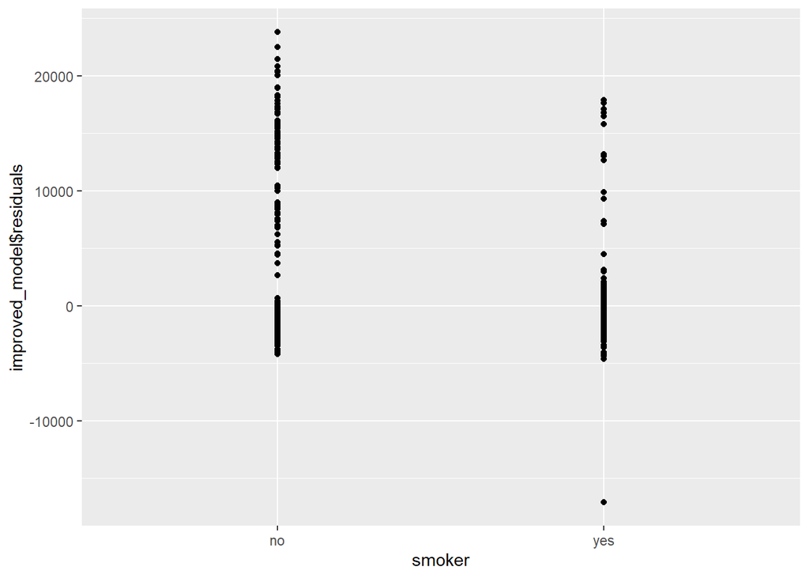

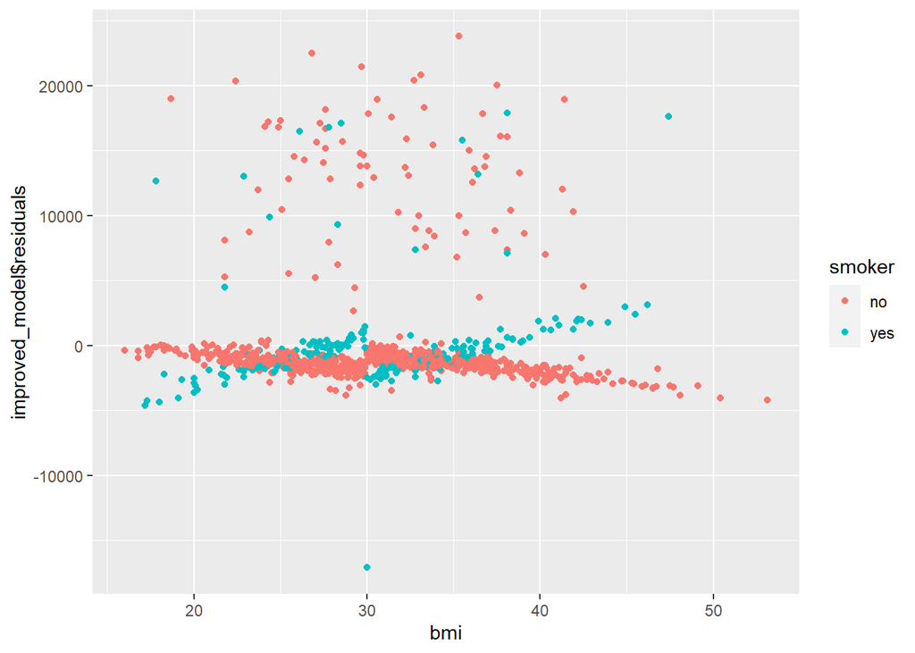

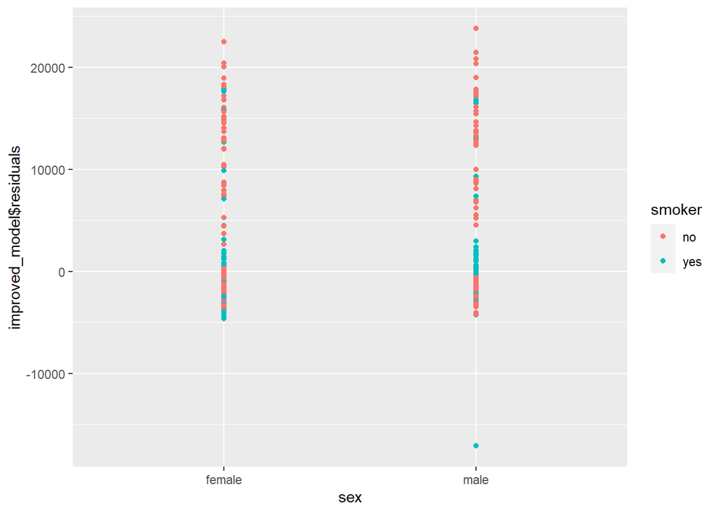

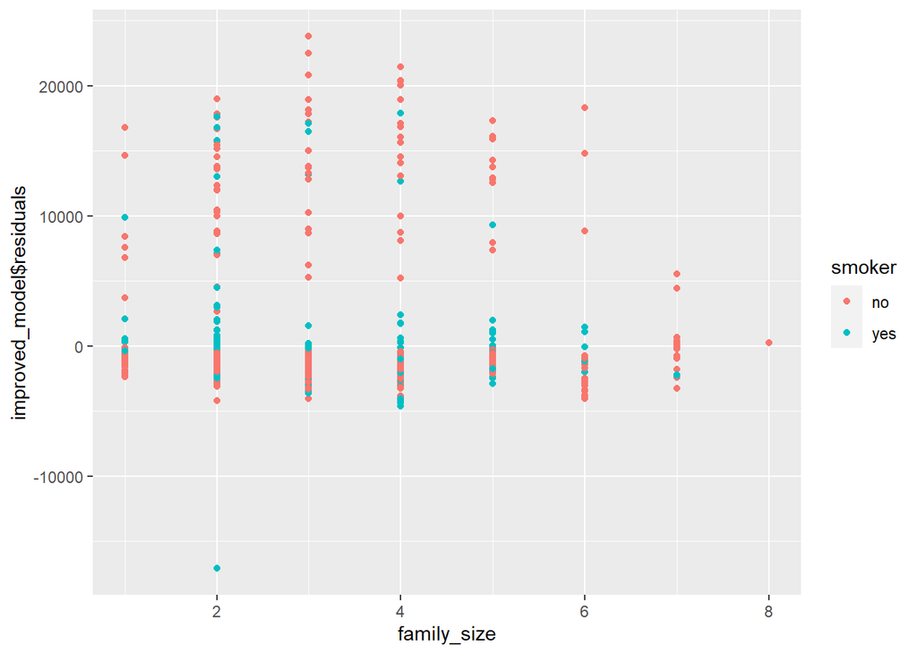

#### **Influential Observations**

```
##        StudRes        Hat        CookD
## 180  5.0835793 0.01141706 0.0171247720
## 242  3.4132472 0.05945689 0.0428592150
## 333 -0.4163789 0.07982446 0.0008854377
## 390  5.3967151 0.01307784 0.0220723535
## 763  4.2396185 0.06501594 0.0722782049
## 819 -0.5105804 0.08805370 0.0014817790
```

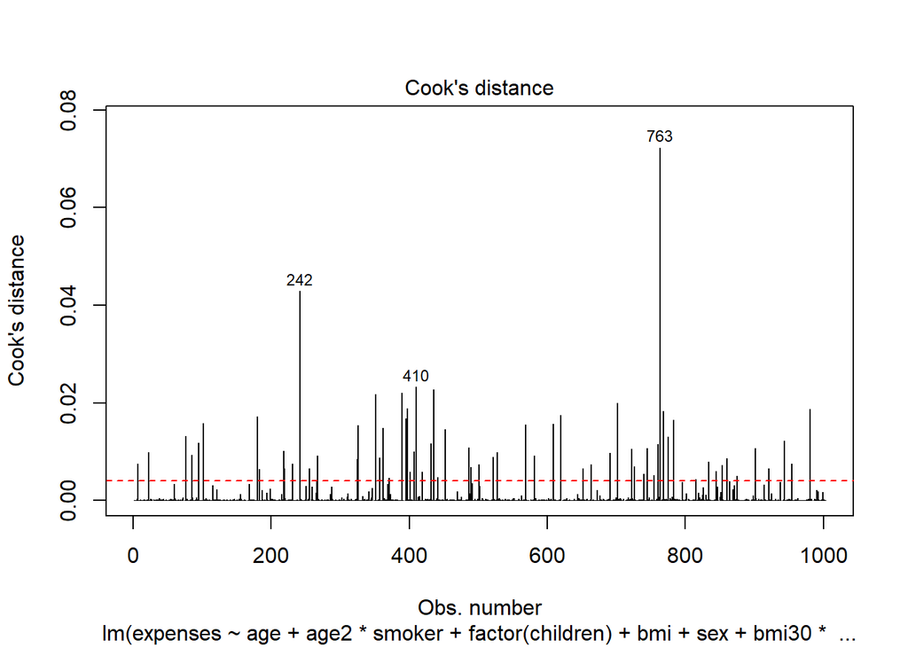

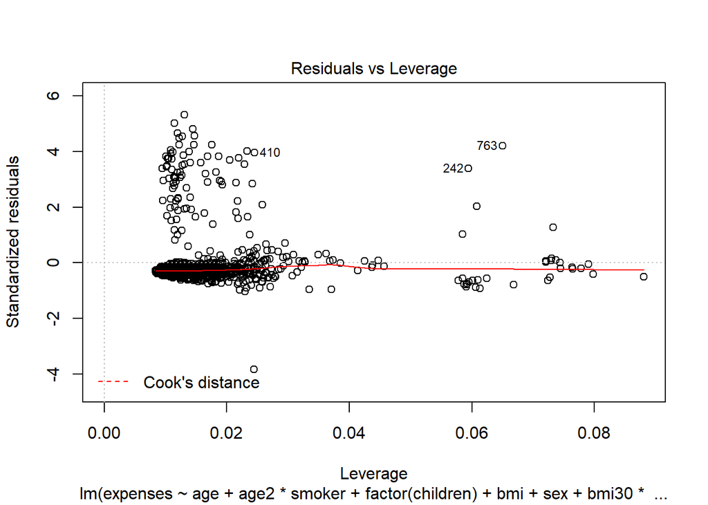

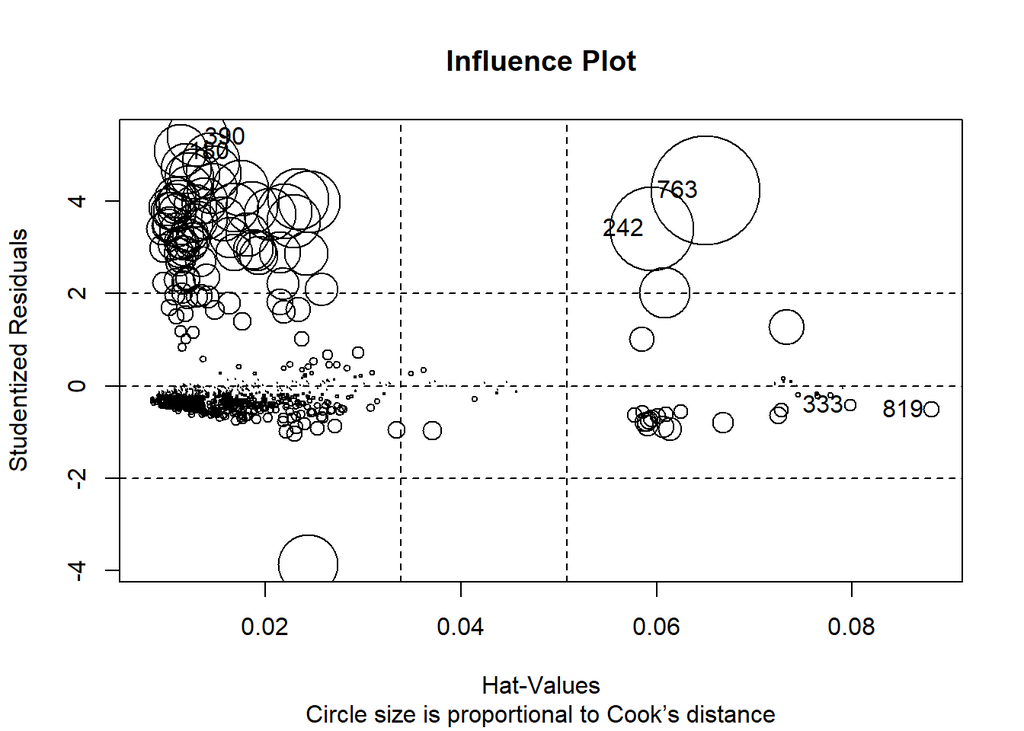

Let’s see what values have the three most influential observations:

```
##        X age    sex  bmi children smoker    region family_size expenses
## 763 1013  61 female 33.3        4     no southeast           6 36580.28
```

```
##       X age    sex  bmi children smoker    region family_size expenses
## 242 322  26 female 29.6        4     no northeast           6 24671.66
```

```
##       X age    sex  bmi children smoker    region family_size expenses
## 410 544  54 female 47.4        0    yes southeast           2 63770.43
```

#### **Compare models**

Here we compare 3 models:

- basic_model
- improved_model
- improved_model_no_outliers: This is the previous model without the three most influental observation

```
## [1] "basic_model"
```

```
## # A tibble: 1 x 4
##   r.squared adj.r.squared    AIC    BIC
##       <dbl>         <dbl>  <dbl>  <dbl>
## 1     0.711         0.710 20432. 20452.
```

```
## [1] "Mallows C_p: 125.05"
```

```
## [1] "improved_model"
```

```
## # A tibble: 1 x 4
##   r.squared adj.r.squared    AIC    BIC
##       <dbl>         <dbl>  <dbl>  <dbl>
## 1     0.859         0.857 19741. 19829.
```

```
## [1] "Mallows C_p: -433.41"
```

```
## [1] "improved_model_no_outliers"
```

```
## # A tibble: 1 x 4
##   r.squared adj.r.squared   AIC   BIC
##       <dbl>         <dbl> <dbl> <dbl>
## 1     0.814         0.812  989. 1038.
```

```
## [1] "Mallows C_p: -982"
```

We get that “improved model” has the best R-squared result (the highest), and that “improved_model_no_ouliers” has the best AIC and BIC results (lowest AIC and BIC).

#### **Features Selection**

Now we will try 4 different methods for feature selection:

1. Forward selection
2. Backward selection
3. Stepwise selection (combination of 1. And 2.)
4. bestglm

**1. Foward Selection**

```
## Start:  AIC=18824.88
## expenses ~ 1
##
##               Df  Sum of Sq        RSS   AIC
## + smoker       1 8.7115e+10 5.4634e+10 17871
## + age          1 1.3078e+10 1.2867e+11 18730
## + bmi          1 4.2331e+09 1.3752e+11 18797
## + family_size  1 6.9449e+08 1.4105e+11 18822
## + sex          1 4.3424e+08 1.4132e+11 18824
## <none>                      1.4175e+11 18825
## + region       3 8.0648e+08 1.4094e+11 18825
##
## Step:  AIC=17870.61
## expenses ~ smoker
##
##               Df  Sum of Sq        RSS   AIC
## + age          1 1.3662e+10 4.0972e+10 17584
## + bmi          1 5.6778e+09 4.8956e+10 17763
## + family_size  1 5.3145e+08 5.4103e+10 17863
## <none>                      5.4634e+10 17871
## + sex          1 2.4327e+07 5.4610e+10 17872
## + region       3 4.1063e+07 5.4593e+10 17876
##
## Step:  AIC=17583.98
## expenses ~ smoker + age
##
##               Df  Sum of Sq        RSS   AIC
## + bmi          1 3899399021 3.7073e+10 17486
## + family_size  1  355920242 4.0616e+10 17577
## <none>                      4.0972e+10 17584
## + sex          1    3421757 4.0969e+10 17586
## + region       3   47066261 4.0925e+10 17589
##
## Step:  AIC=17485.67
## expenses ~ smoker + age + bmi
##
##               Df Sum of Sq        RSS   AIC
## + family_size  1 425179696 3.6647e+10 17476
## <none>                     3.7073e+10 17486
## + sex          1  27919998 3.7045e+10 17487
## + region       3 169886445 3.6903e+10 17487
##
## Step:  AIC=17476.1
## expenses ~ smoker + age + bmi + family_size
##
##          Df Sum of Sq        RSS   AIC
## <none>                3.6647e+10 17476
## + sex     1  31581705 3.6616e+10 17477
## + region  3 172170741 3.6475e+10 17477
```

**2. Backward selection**

```
## Start:  AIC=17478.54
## expenses ~ age + sex + bmi + smoker + region + family_size
##
##               Df  Sum of Sq        RSS   AIC
## - region       3 1.7112e+08 3.6616e+10 17477
## - sex          1 3.0526e+07 3.6475e+10 17477
## <none>                      3.6445e+10 17479
## - family_size  1 4.3123e+08 3.6876e+10 17488
## - bmi          1 4.1079e+09 4.0553e+10 17584
## - age          1 1.1563e+10 4.8008e+10 17753
## - smoker       1 8.8034e+10 1.2448e+11 18709
##
## Step:  AIC=17477.23
## expenses ~ age + sex + bmi + smoker + family_size
##
##               Df  Sum of Sq        RSS   AIC
## - sex          1 3.1582e+07 3.6647e+10 17476
## <none>                      3.6616e+10 17477
## - family_size  1 4.2884e+08 3.7045e+10 17487
## - bmi          1 3.9957e+09 4.0612e+10 17579
## - age          1 1.1639e+10 4.8255e+10 17752
## - smoker       1 8.8314e+10 1.2493e+11 18706
##
## Step:  AIC=17476.1
## expenses ~ age + bmi + smoker + family_size
##
##               Df  Sum of Sq        RSS   AIC
## <none>                      3.6647e+10 17476
## - family_size  1 4.2518e+08 3.7073e+10 17486
## - bmi          1 3.9687e+09 4.0616e+10 17577
## - age          1 1.1692e+10 4.8339e+10 17752
## - smoker       1 8.8718e+10 1.2537e+11 18708
```

**3. Stepwise Selection (a combination of 1. And 2.)**

```
## Start:  AIC=18824.88
## expenses ~ 1
##
##               Df  Sum of Sq        RSS   AIC
## + smoker       1 8.7115e+10 5.4634e+10 17871
## + age          1 1.3078e+10 1.2867e+11 18730
## + bmi          1 4.2331e+09 1.3752e+11 18797
## + family_size  1 6.9449e+08 1.4105e+11 18822
## + sex          1 4.3424e+08 1.4132e+11 18824
## <none>                      1.4175e+11 18825
## + region       3 8.0648e+08 1.4094e+11 18825
##
## Step:  AIC=17870.61
## expenses ~ smoker
##
##               Df  Sum of Sq        RSS   AIC
## + age          1 1.3662e+10 4.0972e+10 17584
## + bmi          1 5.6778e+09 4.8956e+10 17763
## + family_size  1 5.3145e+08 5.4103e+10 17863
## <none>                      5.4634e+10 17871
## + sex          1 2.4327e+07 5.4610e+10 17872
## + region       3 4.1063e+07 5.4593e+10 17876
## - smoker       1 8.7115e+10 1.4175e+11 18825
##
## Step:  AIC=17583.98
## expenses ~ smoker + age
##
##               Df  Sum of Sq        RSS   AIC
## + bmi          1 3.8994e+09 3.7073e+10 17486
## + family_size  1 3.5592e+08 4.0616e+10 17577
## <none>                      4.0972e+10 17584
## + sex          1 3.4218e+06 4.0969e+10 17586
## + region       3 4.7066e+07 4.0925e+10 17589
## - age          1 1.3662e+10 5.4634e+10 17871
## - smoker       1 8.7699e+10 1.2867e+11 18730
##
## Step:  AIC=17485.67
## expenses ~ smoker + age + bmi
##
##               Df  Sum of Sq        RSS   AIC
## + family_size  1 4.2518e+08 3.6647e+10 17476
## <none>                      3.7073e+10 17486
## + sex          1 2.7920e+07 3.7045e+10 17487
## + region       3 1.6989e+08 3.6903e+10 17487
## - bmi          1 3.8994e+09 4.0972e+10 17584
## - age          1 1.1884e+10 4.8956e+10 17763
## - smoker       1 8.8857e+10 1.2593e+11 18710
##
## Step:  AIC=17476.1
## expenses ~ smoker + age + bmi + family_size
##
##               Df  Sum of Sq        RSS   AIC
## <none>                      3.6647e+10 17476
## + sex          1 3.1582e+07 3.6616e+10 17477
## + region       3 1.7217e+08 3.6475e+10 17477
## - family_size  1 4.2518e+08 3.7073e+10 17486
## - bmi          1 3.9687e+09 4.0616e+10 17577
## - age          1 1.1692e+10 4.8339e+10 17752
## - smoker       1 8.8718e+10 1.2537e+11 18708
```

**4. bestglm**

```
## [1] "-----Foward:-----"
```

```
##
## Call:
## lm(formula = expenses ~ smoker + age + bmi + family_size, data = train)
##
## Coefficients:
## (Intercept)    smokeryes          age          bmi  family_size
##    -12598.7      23172.0        243.6        323.4        495.3
```

```
## [1] "-----Backward:-----"
```

```
##
## Call:
## lm(formula = expenses ~ age + bmi + smoker + family_size, data = train)
##
## Coefficients:
## (Intercept)          age          bmi    smokeryes  family_size
##    -12598.7        243.6        323.4      23172.0        495.3
```

```
## [1] "-----Stepwise:-----"
```

```
##
## Call:
## lm(formula = expenses ~ smoker + age + bmi + family_size, data = train)
##
## Coefficients:
## (Intercept)    smokeryes          age          bmi  family_size
##    -12598.7      23172.0        243.6        323.4        495.3
```

```
## [1] "-----bestglm:-----"
```

```
##
## Call:
## lm(formula = y ~ ., data = data.frame(Xy[, c(bestset[-1], FALSE),
##     drop = FALSE], y = y))
##
## Coefficients:
## (Intercept)          age          bmi     children    smokeryes  family_size
##    -14473.2        243.9        327.1      -1091.8      23131.0       1445.7
```

It can be seen that the first 3 methods picked the variables “age”, “bmi”, “smokeryes” and “family_size”, and all methods assign the same coefficients. However the last method picked the same variables and in addition picked “children”, and assigned different coefficients than the first three.

### **Final Model**

We choose “improved_model” as the final model.

Lets examine the its results:

```r
summary(improved_model)
```

```
##
## Call:
## lm(formula = expenses ~ age + age2 * smoker + factor(children) +
##     bmi + sex + bmi30 * smoker + region, data = train)
##
## Residuals:
##      Min       1Q   Median       3Q      Max
## -17098.7  -1747.5  -1215.1   -574.1  23806.1
##
## Coefficients:
##                    Estimate Std. Error t value Pr(>|t|)
## (Intercept)       -6421.762   1130.227  -5.682 1.75e-08 ***
## age                 254.531     10.229  24.884  < 2e-16 ***
## age2                  4.550      1.001   4.547 6.12e-06 ***
## smokeryes         14028.989    620.534  22.608  < 2e-16 ***
## factor(children)1  1105.023    377.411   2.928 0.003491 **
## factor(children)2  1807.289    425.728   4.245 2.39e-05 ***
## factor(children)3  1761.595    486.235   3.623 0.000306 ***
## factor(children)4  4335.044   1062.909   4.078 4.90e-05 ***
## factor(children)5  2092.056   1195.398   1.750 0.080414 .
## bmi                 152.043     39.608   3.839 0.000132 ***
## sexmale            -574.291    287.084  -2.000 0.045728 *
## bmi30             -1330.270    500.596  -2.657 0.008003 **
## regionnorthwest    -310.280    411.429  -0.754 0.450938
## regionsoutheast   -1025.300    409.099  -2.506 0.012362 *
## regionsouthwest   -1188.910    410.824  -2.894 0.003888 **
## age2:smokeryes       -2.286      1.986  -1.151 0.250001
## smokeryes:bmi30   19461.689    706.677  27.540  < 2e-16 ***
## ---
## Signif. codes:  0 '***' 0.001 '**' 0.01 '*' 0.05 '.' 0.1 ' ' 1
##
## Residual standard error: 4503 on 986 degrees of freedom
## Multiple R-squared:  0.8589, Adjusted R-squared:  0.8567
## F-statistic: 375.2 on 16 and 986 DF,  p-value: < 2.2e-16
```

**F-test:**  
The F-test is used to performs a “joint” hypothesis testing:  
H0: All of the regression coefficients are equal to zero (the model has no predictive capability)  
H1: Otherwise (meaning at least one of the coefficients isn’t equal to zero)

**T-test(s):**  
Each T-test is used to check the predictive capability of one feature only:  
H0: The coefficient of the i’th feature is equal to zero (there is no linear connection between the outcome and the feature)  
H1: Otherwise

Here we get significant results for almost all variables, meaning there is an evidence that these variables have linear connection to the oucome.

### **Final Model Evaluaion**

Evaluate model on test set:

```
## [1] "MSE final model:"
```

```
## [1] 78326712
```